# Minería de datos: PEC3 - Clasificación con árboles de decisión

César Alcívar

7/12/2021

```r
library(tidyverse)
```

# 1 Introducción

```r
data <- read.csv('credit.csv', stringsAsFactors = T)
head(data)
```

```
##   checking_balance months_loan_duration credit_history   purpose amount
## 1           < 0 DM                    6       critical  radio/tv   1169
## 2       1 - 200 DM                   48         repaid  radio/tv   5951
## 3          unknown                   12       critical education   2096
## 4           < 0 DM                   42         repaid furniture   7882
## 5           < 0 DM                   24        delayed car (new)   4870
## 6          unknown                   36         repaid education   9055
##   savings_balance employment_length installment_rate personal_status
## 1         unknown           > 7 yrs                4     single male
## 2        < 100 DM         1 - 4 yrs                2          female
## 3        < 100 DM         4 - 7 yrs                2     single male
## 4        < 100 DM         4 - 7 yrs                2     single male
## 5        < 100 DM         1 - 4 yrs                3     single male
## 6         unknown         1 - 4 yrs                2     single male
##   other_debtors residence_history                 property age installment_plan
```

[output cut: 20 more lines]

# 2 Análisis descriptivo y de correlaciones

## 2.1 Análisis inicial

Empezaremos haciendo análisis descriptivo de los datos con la objetivo de tener una idea general del dataset que disponemos.

### 2.1.1 Exploración de la base de datos

```r
dim(data)
```

```
## [1] 1000   21
```

Se obtiene las dimensiones del dataset mediante la función `dim()`. Tenemos 1000 registros (filas) y 21 variables (columnas).

```r
str(data)
```

```
## 'data.frame':    1000 obs. of  21 variables:
##  $ checking_balance    : Factor w/ 4 levels "< 0 DM","> 200 DM",..: 1 3 4 1 1 4 4 3 4 3 ...
##  $ months_loan_duration: int  6 48 12 42 24 36 24 36 12 30 ...
##  $ credit_history      : Factor w/ 5 levels "critical","delayed",..: 1 5 1 5 2 5 5 5 5 1 ...
##  $ purpose             : Factor w/ 10 levels "business","car (new)",..: 8 8 5 6 2 5 6 3 8 2 ...
##  $ amount              : int  1169 5951 2096 7882 4870 9055 2835 6948 3059 5234 ...
##  $ savings_balance     : Factor w/ 5 levels "< 100 DM","> 1000 DM",..: 5 1 1 1 1 5 4 1 2 1 ...
##  $ employment_length   : Factor w/ 5 levels "> 7 yrs","0 - 1 yrs",..: 1 3 4 4 3 3 1 3 4 5 ...
##  $ installment_rate    : int  4 2 2 2 3 2 3 2 2 4 ...
##  $ personal_status     : Factor w/ 4 levels "divorced male",..: 4 2 4 4 4 4 4 4 1 3 ...
##  $ other_debtors       : Factor w/ 3 levels "co-applicant",..: 3 3 3 2 3 3 3 3 3 3 ...
##  $ residence_history   : int  4 2 3 4 4 4 4 2 4 2 ...
##  $ property            : Factor w/ 4 levels "building society savings",..: 3 3 3 1 4 4 1 2 3 2 ...
##  $ age                 : int  67 22 49 45 53 35 53 35 61 28 ...
##  $ installment_plan    : Factor w/ 3 levels "bank","none",..: 2 2 2 2 2 2 2 2 2 2 ...
##  $ housing             : Factor w/ 3 levels "for free","own",..: 2 2 2 1 1 1 2 3 2 2 ...
##  $ existing_credits    : int  2 1 1 1 2 1 1 1 1 2 ...
##  $ default             : int  1 2 1 1 2 1 1 1 1 2 ...
##  $ dependents          : int  1 1 2 2 2 2 1 1 1 1 ...
##  $ telephone           : Factor w/ 2 levels "none","yes": 2 1 1 1 1 2 1 2 1 1 ...
##  $ foreign_worker      : Factor w/ 2 levels "no","yes": 2 2 2 2 2 2 2 2 2 2 ...
##  $ job                 : Factor w/ 4 levels "mangement self-employed",..: 2 2 4 2 2 4 2 1 4 1 ...
```

Con la función `str`, se observan 13 variables categóricas y 7 variables continuas. A continuación, se describen las variables de dataset:

- checking_balance: Estado de la cuenta corriente existente
- months_loan_duration: Duración del préstamo en meses
- credit_history: los antecedentes del historial crediticio.
- purpose: las posibles razones para obtener un préstamo.
- amount: la cantidad del prestamo solicitado.
- savings_balance: dinero disponible en ahorros y bonos.
- employment_length: desde cuando tiene empleo.
- installment_rate: la tasa de pago en porcentaje de la renta disponible.
- personal_status: estado civil y sexo.
- other_debtors: otras deudoras.
- residence_history: número de años en la residencia actual.
- property: describe el tipo de propiedad que se va a comprar.
- age: Edad.
- installment_plan: otros Planes de Cuotas.
- housing: Alojamiento.
- existing_credits: el número de crédito existentes en este banco.
- dependents
- telephone: tiene teléfono.
- foreign_worker: es trabajador extranjero.
- job: decripción del trabajo.
- default: Tiene riegos el crédito.

```r
summary(data)
```

```
##    checking_balance months_loan_duration                credit_history
##  < 0 DM    :274     Min.   : 4.0         critical              :293
##  > 200 DM  : 63     1st Qu.:12.0         delayed               : 88
##  1 - 200 DM:269     Median :18.0         fully repaid          : 40
##  unknown   :394     Mean   :20.9         fully repaid this bank: 49
##                     3rd Qu.:24.0         repaid                :530
##                     Max.   :72.0
##
##        purpose        amount           savings_balance  employment_length
##  radio/tv  :280   Min.   :  250   < 100 DM     :603    > 7 yrs   :253
##  car (new) :234   1st Qu.: 1366   > 1000 DM    : 48    0 - 1 yrs :172
##  furniture :181   Median : 2320   101 - 500 DM :103    1 - 4 yrs :339
##  car (used):103   Mean   : 3271   501 - 1000 DM: 63    4 - 7 yrs :174
##  business  : 97   3rd Qu.: 3972   unknown      :183    unemployed: 62
##  education : 50   Max.   :18424
##  (Other)   : 55
##  installment_rate      personal_status      other_debtors residence_history
##  Min.   :1.000    divorced male: 50    co-applicant: 41   Min.   :1.000
##  1st Qu.:2.000    female       :310    guarantor   : 52   1st Qu.:2.000
##  Median :3.000    married male : 92    none        :907   Median :3.000
##  Mean   :2.973    single male  :548                       Mean   :2.845
##  3rd Qu.:4.000                                            3rd Qu.:4.000
##  Max.   :4.000                                            Max.   :4.000
##
##                      property        age        installment_plan     housing
##  building society savings:232   Min.   :19.00   bank  :139       for free:108
##  other                   :332   1st Qu.:27.00   none  :814       own     :713
##  real estate             :282   Median :33.00   stores: 47       rent    :179
##  unknown/none            :154   Mean   :35.55
##                                 3rd Qu.:42.00
##                                 Max.   :75.00
##
##  existing_credits    default      dependents    telephone  foreign_worker
##  Min.   :1.000    Min.   :1.0   Min.   :1.000   none:596   no : 37
##  1st Qu.:1.000    1st Qu.:1.0   1st Qu.:1.000   yes :404   yes:963
##  Median :1.000    Median :1.0   Median :1.000
##  Mean   :1.407    Mean   :1.3   Mean   :1.155
##  3rd Qu.:2.000    3rd Qu.:2.0   3rd Qu.:1.000
##  Max.   :4.000    Max.   :2.0   Max.   :2.000
##
##                       job
##  mangement self-employed:148
##  skilled employee       :630
##  unemployed non-resident: 22
##  unskilled resident     :200
##
##
##
```

```r
missing <- data[is.na(data),]
dim(missing)
```

```
## [1]  0 21
```

Se observa que no existen valores nulos, por lo tanto, se dispone de un dataset igual sin cambios para realizar el respectivo análisis.

### 2.1.2 Visualización

Para mostrar la distribución de algunas variables, se utilizará la siguiente función:

```r
bar_risk_plot = function(field, title) {
  ggplot(data, aes(default, fill= field)) +
  geom_bar(position = position_dodge(0.8), width = 0.7) +
  labs(x="Tipo Riesgo", y="Solicitantes de credito") +
  guides(fill=guide_legend(title=title)) +
  theme_bw()
}
```

```r
data$default <- ifelse(data$default == 1, "Sin riesgo", "Con riesgo")
```

En la sentencia anterior, se categorizan a los clientes del banco de la siguiente manera:

- Solicitantes sin riesgo (1): clientes que posiblemente tengan capacidad de pagar un crédito.
- Solicitantes con riesgo (2): clientes que posiblemente no tengan capacidad de pagar un crédito.

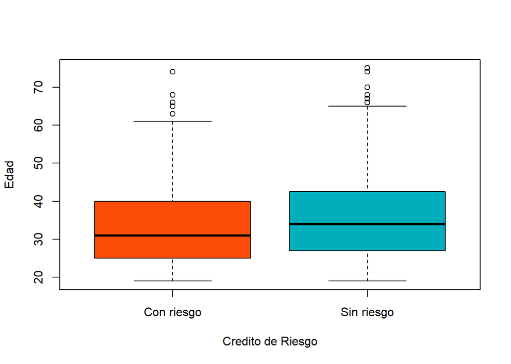

```r
boxplot(data$age~data$default, col =c("#FC4E07", "#00AFBB"), ylab = "Edad", xlab = "Credito de Riesgo")
```

Se visualiza en la gráfica, que los solicitantes con riesgos son de menor edad que los solicitantes sin riesgos. Quizás, esto se deba a que jóvenes tengan menos experiencia en planificación financiera.

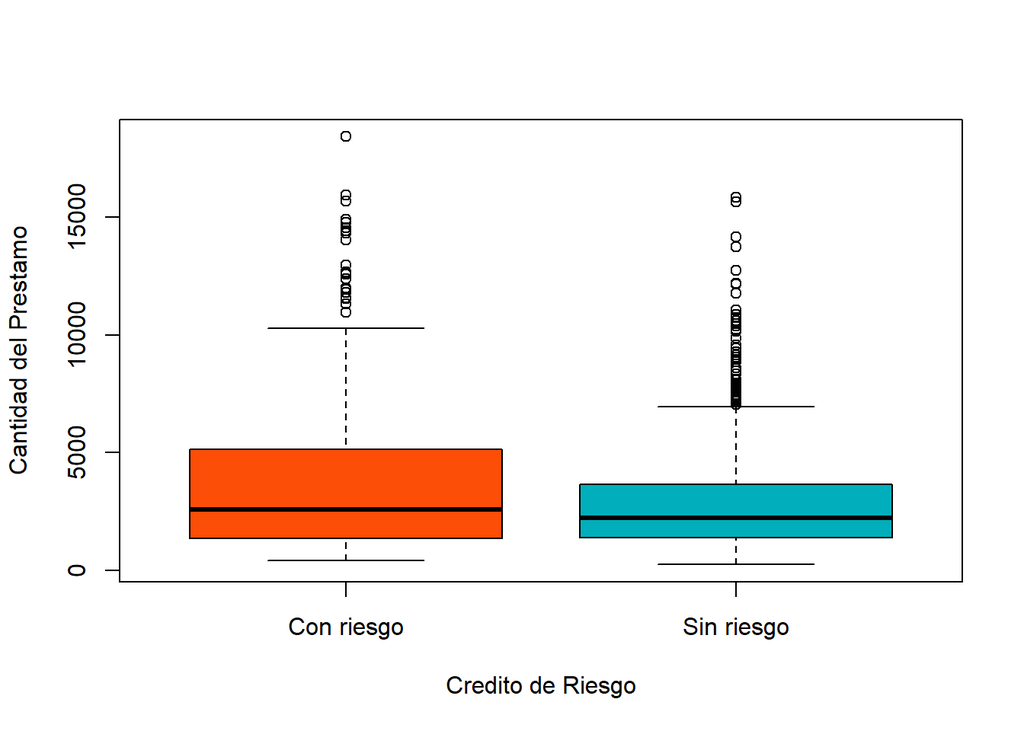

```r
boxplot(data$amount~data$default, col =c("#FC4E07", "#00AFBB"), ylab = "Cantidad del Prestamo", xlab = "Credito de Riesgo")
```

Mediante la gráfica, se puede observar que los solicitantes con riesgos tienden a tener prestamos más elevados. La causa podría ser por sobreestimación de la capacidad de pago.

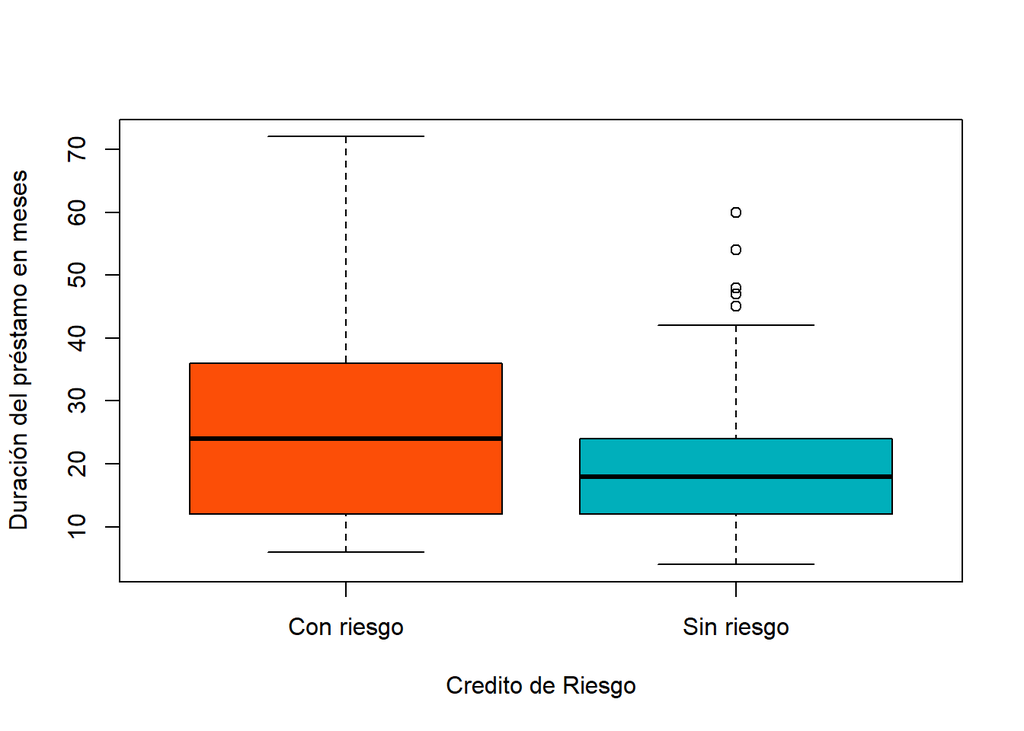

```r
boxplot(data$months_loan_duration~data$default, col =c("#FC4E07", "#00AFBB"), ylab = "Duración del préstamo en meses", xlab = "Credito de Riesgo")
```

En la gráfica se observa que los solicitantes con riesgos tienden a pedir préstamos con periodos más largos de pago, posiblemente, debido a que sus ingresos económicos mensuales son más bajos en comparación con los clientes sin riesgos.

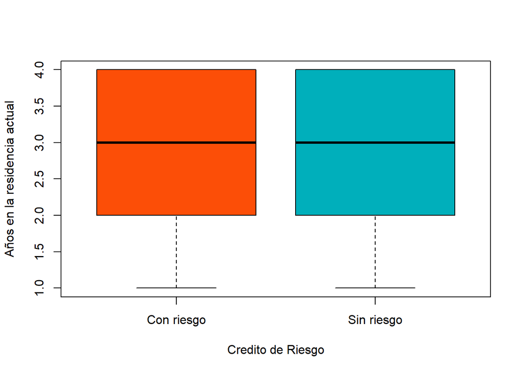

```r
boxplot(data$residence_history~data$default, col =c("#FC4E07", "#00AFBB"), ylab = "Años en la residencia actual", xlab = "Credito de Riesgo")
```

No se visualiza diferencias significativas en los años de residencia actual entre los solicitantes.

```r
table_CB <- table(data$checking_balance, data$default)
table_CB
```

```
##
##              Con riesgo Sin riesgo
##   < 0 DM            135        139
##   > 200 DM           14         49
##   1 - 200 DM        105        164
##   unknown            46        348
```

```r
prop.table(table_CB, margin = 1)
```

```
##
##              Con riesgo Sin riesgo
##   < 0 DM      0.4927007  0.5072993
##   > 200 DM    0.2222222  0.7777778
##   1 - 200 DM  0.3903346  0.6096654
##   unknown     0.1167513  0.8832487
```

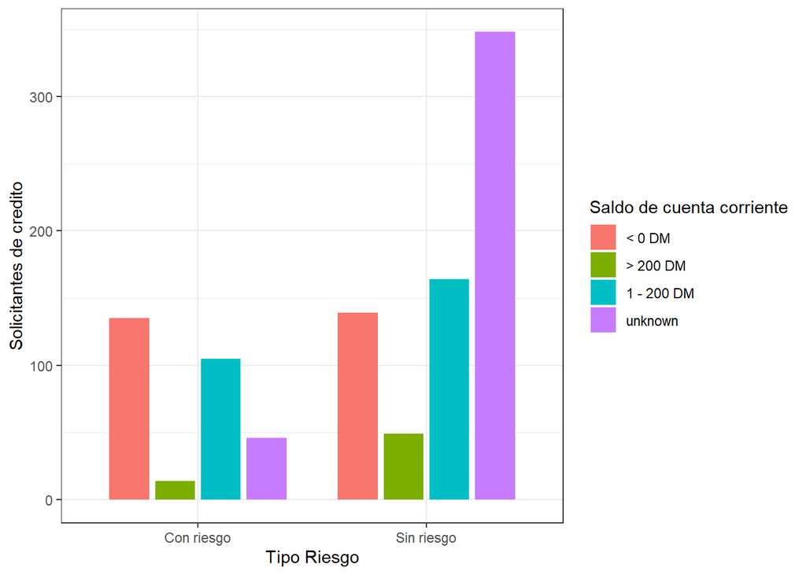

```r
bar_risk_plot(data$checking_balance,"Saldo de cuenta corriente")
```

```r
table_OD <- table(data$other_debtors, data$default)
table_OD
```

```
##
##                Con riesgo Sin riesgo
##   co-applicant         18         23
##   guarantor            10         42
##   none                272        635
```

```r
prop.table(table_OD, margin = 1)
```

```
##
##                Con riesgo Sin riesgo
##   co-applicant  0.4390244  0.5609756
##   guarantor     0.1923077  0.8076923
##   none          0.2998897  0.7001103
```

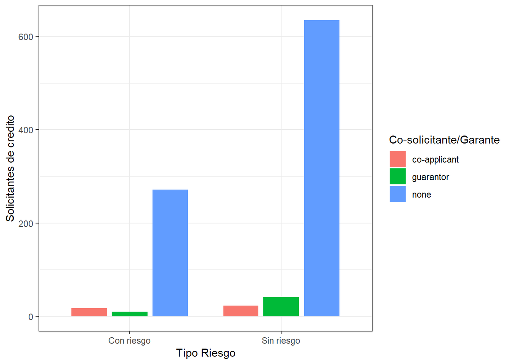

```r
bar_risk_plot(data$other_debtors,"Co-solicitante/Garante")
```

En la gráfica se destaca que la mayoría los solicitantes sin riesgos no han sido garantes ni co-solicitantes de préstamos bancarios. Por otro lado, en la tabla de contingencia se observa que el 80% de los garantes han sido personas sin riesgo.

```r
table_HI <- table(data$credit_history, data$default)
table_HI
```

```
##
##                          Con riesgo Sin riesgo
##   critical                       50        243
##   delayed                        28         60
##   fully repaid                   25         15
##   fully repaid this bank         28         21
##   repaid                        169        361
```

```r
prop.table(table_HI, margin = 1)
```

```
##
##                          Con riesgo Sin riesgo
##   critical                0.1706485  0.8293515
##   delayed                 0.3181818  0.6818182
##   fully repaid            0.6250000  0.3750000
##   fully repaid this bank  0.5714286  0.4285714
##   repaid                  0.3188679  0.6811321
```

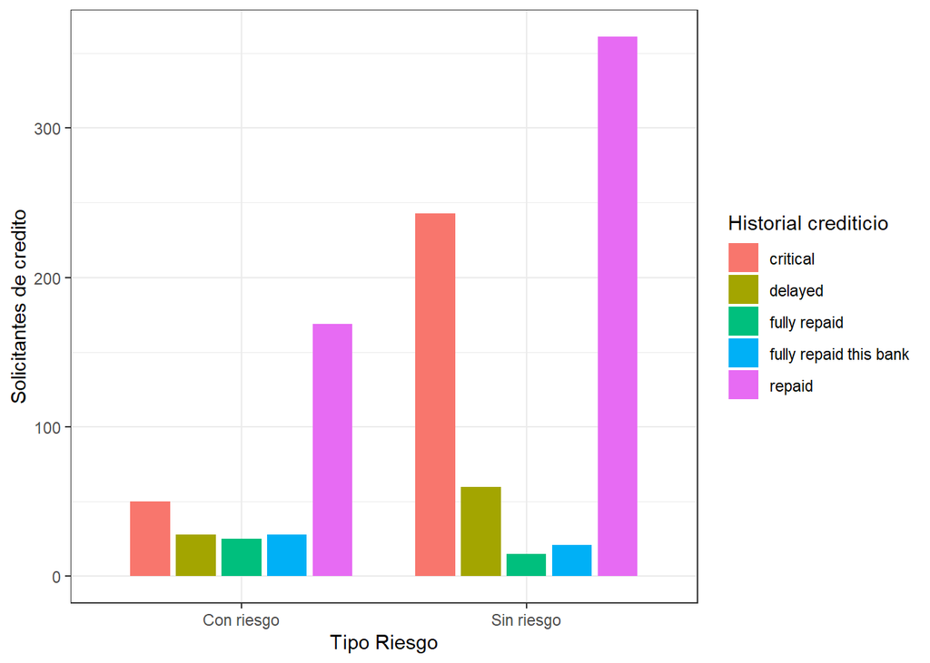

```r
bar_risk_plot(data$credit_history,"Historial crediticio")
```

En la gráfica se observa que los solicitantes sin riesgos son los que mejores pagan los créditos, tal vez por ese motivo tienen otros créditos con diferentes entidades bancarias. Esto se puede confirmar con los datos de la tabla de contingencia. El 82% de los solicitantes que han requerido un crédito son personas sin riesgos. Como dato curioso, el 62% de las personas que pagan totalmente los reembolsos son solicitantes con riesgo.

```r
table_SB <- table(data$savings_balance, data$default)
table_SB
```

```
##
##                 Con riesgo Sin riesgo
##   < 100 DM             217        386
##   > 1000 DM              6         42
##   101 - 500 DM          34         69
##   501 - 1000 DM         11         52
##   unknown               32        151
```

```r
prop.table(table_SB, margin = 1)
```

```
##
##                 Con riesgo Sin riesgo
##   < 100 DM       0.3598673  0.6401327
##   > 1000 DM      0.1250000  0.8750000
##   101 - 500 DM   0.3300971  0.6699029
##   501 - 1000 DM  0.1746032  0.8253968
##   unknown        0.1748634  0.8251366
```

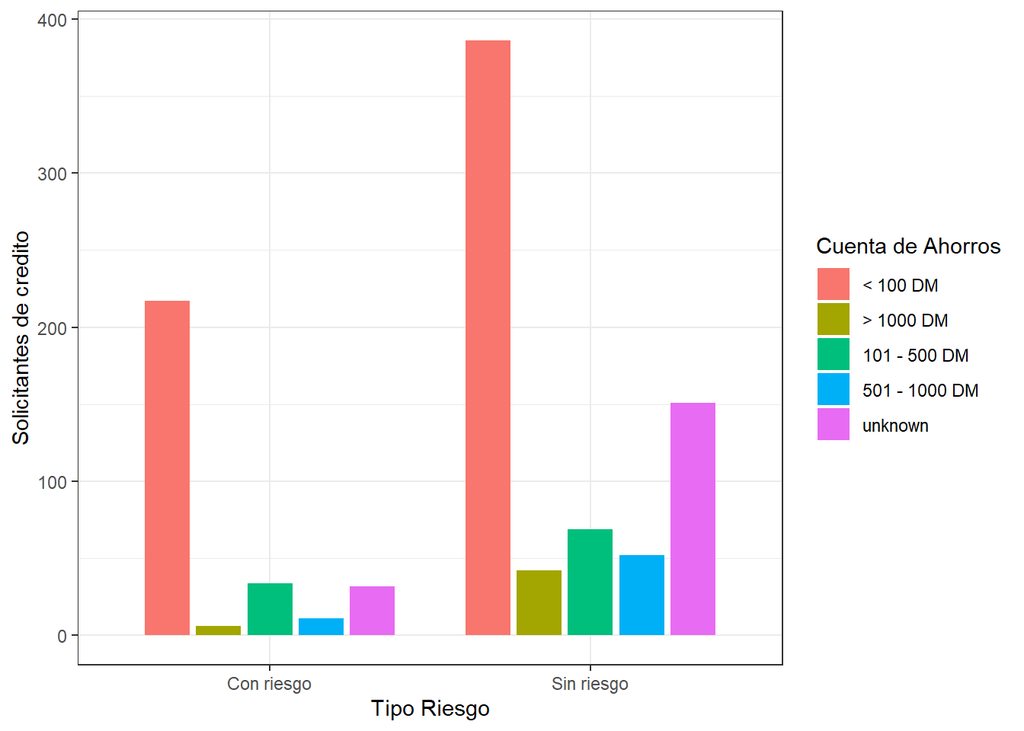

```r
bar_risk_plot(data$savings_balance,"Cuenta de Ahorros")
```

Se observa que los solicitantes sin riesgos tienen más ahorros. Como dato llamativo, el 82% de las personas que se les desconoce el saldo de sus ahorros, pertenecen a los solicitantes sin riesgos.

```r
table_PU <- table(data$purpose, data$default)
table_PU
```

```
##
##                       Con riesgo Sin riesgo
##   business                    34         63
##   car (new)                   89        145
##   car (used)                  17         86
##   domestic appliances          4          8
##   education                   22         28
##   furniture                   58        123
##   others                       5          7
##   radio/tv                    62        218
##   repairs                      8         14
##   retraining                   1          8
```

```r
prop.table(table_PU, margin = 1)
```

```
##
##                       Con riesgo Sin riesgo
##   business             0.3505155  0.6494845
##   car (new)            0.3803419  0.6196581
##   car (used)           0.1650485  0.8349515
##   domestic appliances  0.3333333  0.6666667
##   education            0.4400000  0.5600000
##   furniture            0.3204420  0.6795580
##   others               0.4166667  0.5833333
##   radio/tv             0.2214286  0.7785714
##   repairs              0.3636364  0.6363636
##   retraining           0.1111111  0.8888889
```

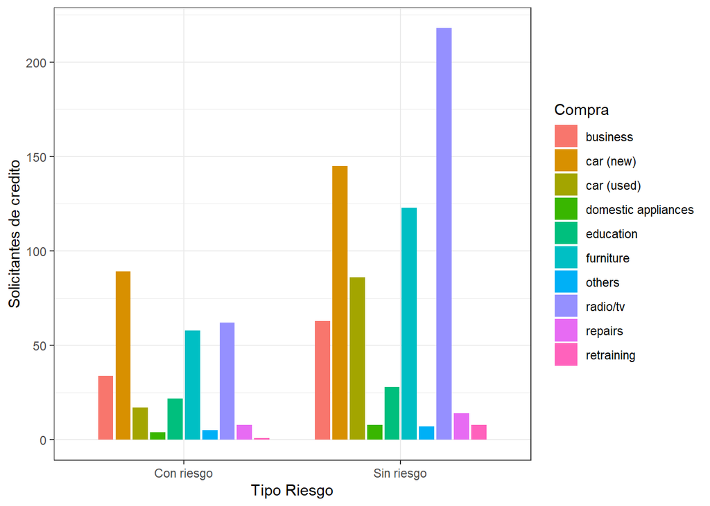

```r
bar_risk_plot(data$purpose,"Compra")
```

Se puede observar que los solicitantes incumplidos, la mayoría solicita un prestamo para comprar autos nuevos. Por otra parte, los solicitantes sin riesgos piden prestamos para comprar electrodomesticos, carros nuevos y usados.

```r
fields = c("months_loan_duration", "amount", "installment_rate", "residence_history", "age", "existing_credits", "dependents")
cor(data[, fields])
```

```
##                      months_loan_duration      amount installment_rate
## months_loan_duration           1.00000000  0.62498420       0.07474882
## amount                         0.62498420  1.00000000      -0.27131570
## installment_rate               0.07474882 -0.27131570       1.00000000
## residence_history              0.03406720  0.02892632       0.04930237
## age                           -0.03613637  0.03271642       0.05826568
## existing_credits              -0.01128360  0.02079455       0.02166874
## dependents                    -0.02383448  0.01714215      -0.07120694
##                      residence_history         age existing_credits  dependents
## months_loan_duration        0.03406720 -0.03613637      -0.01128360 -0.02383448
## amount                      0.02892632  0.03271642       0.02079455  0.01714215
## installment_rate            0.04930237  0.05826568       0.02166874 -0.07120694
## residence_history           1.00000000  0.26641918       0.08962523  0.04264343
## age                         0.26641918  1.00000000       0.14925358  0.11820083
## existing_credits            0.08962523  0.14925358       1.00000000  0.10966670
## dependents                  0.04264343  0.11820083       0.10966670  1.00000000
```

Con la matriz de correlación se observa que existe una relación lineal de 0.62 entre las variables `amount` y `months_loan_duration`. Cuanto más alto sea el crédito, más meses se pide pagar dicho crédito.

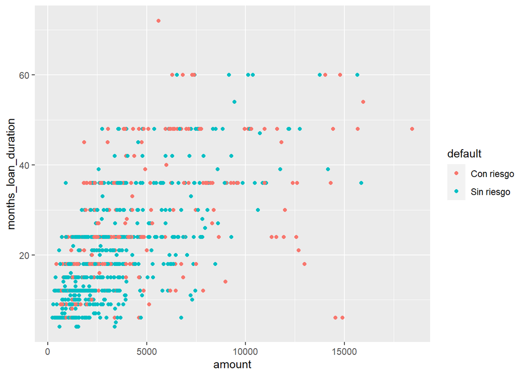

```r
ggplot(data, aes(amount, months_loan_duration, color=default, fill=default)) + geom_point()
```

# 3 Primer árbol de decisión

```r
if(!require(C50)){
    install.packages('C50', repos='http://cran.us.r-project.org')
    library(C50)
}
```

Para evaluar el modelo árbol de decisión, se divide el dataset en un conjunto de entrenamiento y un conjunto de prueba. El conjunto de entrenamiento es el subconjunto del conjunto original de datos utilizado para construir un primer modelo; y el conjunto de prueba, el subconjunto del conjunto original de datos utilizado para evaluar la calidad del modelo.

Para dividir el dataset se utiliza la función `sample.split` del paquete `caTools`.

```r
if(!require(caTools)){
    install.packages('caTools')
  library(caTools)
}
```

Se toma el 80% de los datos como conjunto de entrenamiento, y el 20% restante como conjunto de prueba:

```r
set.seed(1234)
split <- sample.split(data$default, SplitRatio = 0.80)
# Dataset de entrenamiento
training_set <- subset(data, split == TRUE)
# Dataset de prueba
test_set <- subset(data, split == FALSE)

list('entrenamiento'=nrow(training_set), "prueba"=nrow(test_set))
```

```
## $entrenamiento
## [1] 800
##
## $prueba
## [1] 200
```

Se observa que de los 1000 registros del dataset, se tomaron 800 registros aleatorios para el entrenamiento y 200 registros aleatorias para la prueba.

```r
# Se separan los datos de entrenamiento sin la variable clasificadora
trainX <- training_set[,"default"!= names(data)]
# Se separa la variable clasificadora para el entrenamiento
trainy <- training_set[,c('default')]

# Se separan los datos de prueba sin la variable clasificadora
testX<- test_set[,"default"!= names(data)]
# Se separa la variable clasificadora para la prueba
testy<- test_set[,c('default')]
```

```r
summary(trainX)
```

```
##    checking_balance months_loan_duration                credit_history
##  < 0 DM    :223     Min.   : 4.00        critical              :235
##  > 200 DM  : 44     1st Qu.:12.00        delayed               : 74
##  1 - 200 DM:211     Median :18.00        fully repaid          : 32
##  unknown   :322     Mean   :20.89        fully repaid this bank: 41
##                     3rd Qu.:24.00        repaid                :418
##                     Max.   :72.00
##
##        purpose        amount           savings_balance  employment_length
##  radio/tv  :227   Min.   :  250   < 100 DM     :473    > 7 yrs   :196
##  car (new) :189   1st Qu.: 1342   > 1000 DM    : 40    0 - 1 yrs :140
##  furniture :143   Median : 2318   101 - 500 DM : 93    1 - 4 yrs :275
##  car (used): 84   Mean   : 3319   501 - 1000 DM: 51    4 - 7 yrs :143
##  business  : 79   3rd Qu.: 4070   unknown      :143    unemployed: 46
##  education : 39   Max.   :18424
##  (Other)   : 39
##  installment_rate      personal_status      other_debtors residence_history
##  Min.   :1.000    divorced male: 36    co-applicant: 28   Min.   :1.000
##  1st Qu.:2.000    female       :246    guarantor   : 47   1st Qu.:2.000
##  Median :3.000    married male : 81    none        :725   Median :3.000
##  Mean   :2.961    single male  :437                       Mean   :2.876
##  3rd Qu.:4.000                                            3rd Qu.:4.000
##  Max.   :4.000                                            Max.   :4.000
##
##                      property        age        installment_plan     housing
##  building society savings:186   Min.   :19.00   bank  :110       for free: 90
##  other                   :261   1st Qu.:26.00   none  :653       own     :569
##  real estate             :227   Median :33.00   stores: 37       rent    :141
##  unknown/none            :126   Mean   :35.31
##                                 3rd Qu.:42.00
##                                 Max.   :75.00
##
##  existing_credits   dependents    telephone  foreign_worker
##  Min.   :1.000    Min.   :1.000   none:470   no : 31
##  1st Qu.:1.000    1st Qu.:1.000   yes :330   yes:769
##  Median :1.000    Median :1.000
##  Mean   :1.403    Mean   :1.154
##  3rd Qu.:2.000    3rd Qu.:1.000
##  Max.   :4.000    Max.   :2.000
##
##                       job
##  mangement self-employed:117
##  skilled employee       :508
##  unemployed non-resident: 16
##  unskilled resident     :159
##
##
##
```

Después de la extracción aleatoria de los datos de entrenamiento, se revisan para asegurarnos de no obtener clasificadores sesgados por los valores que contiene cada muestra. En este caso, se verifica que la proporción es más o menos constante en los dos conjuntos.

## 3.1 Creación del modelo, calidad del modelo y extracción de reglas

Se crea el árbol de decisión usando los datos de entrenamiento.

```r
trainy = as.factor(trainy)
model <- C50::C5.0(trainX, trainy, rules=TRUE)
summary(model)
```

```
##
## Call:
## C5.0.default(x = trainX, y = trainy, rules = TRUE)
##
##
## C5.0 [Release 2.07 GPL Edition]      Wed Dec 15 18:08:38 2021
## -------------------------------
##
## Class specified by attribute `outcome'
##
## Read 800 cases (21 attributes) from undefined.data
##
## Rules:
##
## Rule 1: (16, lift 3.1)
##  checking_balance in {< 0 DM, 1 - 200 DM}
##  credit_history = repaid
##  purpose = car (new)
##  installment_rate > 2
##  personal_status = female
##  other_debtors = none
##  ->  class Con riesgo  [0.944]
##
## Rule 2: (31/1, lift 3.1)
##  checking_balance in {< 0 DM, 1 - 200 DM}
##  months_loan_duration > 42
##  savings_balance in {< 100 DM, > 1000 DM, 101 - 500 DM}
##  employment_length in {> 7 yrs, 0 - 1 yrs, 1 - 4 yrs, 4 - 7 yrs}
##  residence_history > 1
##  ->  class Con riesgo  [0.939]
##
## Rule 3: (12, lift 3.1)
##  checking_balance in {< 0 DM, 1 - 200 DM}
##  credit_history = fully repaid
##  amount <= 5711
##  residence_history > 2
##  ->  class Con riesgo  [0.929]
##
## Rule 4: (7, lift 3.0)
##  checking_balance in {< 0 DM, 1 - 200 DM}
```

[output cut: 160 more lines]

```
##   41.13% purpose
##   19.75% credit_history
##   15.63% savings_balance
##   12.63% months_loan_duration
##    7.63% residence_history
##    7.38% personal_status
##    4.63% employment_length
##    4.00% job
##    3.00% dependents
##    2.00% installment_rate
##    0.75% property
##    0.38% housing
##
##
## Time: 0.0 secs
```

En `Errors` se muestra el número y porcentaje de casos mal clasificados en el subconjunto de entrenamiento. El árbol obtenido clasifica erróneamente 104 de los 800 casos dados, con una tasa de error del 13.0%.

# 4 Explicación de las reglas obtenidas

Se visualizan las reglas extraídas por el algoritmo C5, el atributo más útil o el que permite separar mejor los datos, es el atributo `checking_balance`. Para analizar las reglas obtenidas se debe responde a la siguiente pregunta:

¿Cuál es la mejor secuencia de preguntas para saber, a partir de la descripción de una muestra en términos de sus atributos, a qué clase corresponde?

## 4.1 Regla 1

```r
## Rule 1: (16, lift 3.1)
##  checking_balance in {< 0 DM, 1 - 200 DM}
##  credit_history = repaid
##  purpose = car (new)
##  installment_rate > 2
##  personal_status = female
##  other_debtors = none
##  ->  class Con riesgo  [0.944]
```

Con la regla 1 se concluye que, si el saldo de la cuenta corriente es de “< 0 DM” o de “1 - 200 DM”, si los creditos pasados los pagaba a traves de reembolsos que no cubren la totalidad del pago, si el préstamo es para comprar un auto nuevo, si la tasa de pago de la renta es mayor a 2, si es mujer, si no ha sido ni garante ni co-solicitante de un préstamo, existe la probabilidad del 94% de no pagar el crédito.

## 4.2 Regla 2

```r
## Rule 2: (31/1, lift 3.1)
##  checking_balance in {< 0 DM, 1 - 200 DM}
##  months_loan_duration > 42
##  savings_balance in {< 100 DM, > 1000 DM, 101 - 500 DM}
##  employment_length in {> 7 yrs, 0 - 1 yrs, 1 - 4 yrs, 4 - 7 yrs}
##  residence_history > 1
##  ->  class Con riesgo  [0.939]
```

Con la regla 2 se concluye que, si el saldo en la cuenta corriente es de “< 0 DM” o de “1 - 200 DM”, si la duración del préstamo es mayor a 42 meses, si la cuenta de ahorro tiene un saldo de “< 100 DM” o de “101 - 500 DM” o de “> 1000 DM”, si tiene empleo, si tiene más de un año en la residencia actual, existe la probabilidad del 93.9% de no pagar el crédito.

## 4.3 Regla 3

```r
## Rule 3: (12, lift 3.1)
##  checking_balance in {< 0 DM, 1 - 200 DM}
##  credit_history = fully repaid
##  amount <= 5711
##  residence_history > 2
##  ->  class Con riesgo  [0.929]
```

Con la regla 3 se concluye que, si el saldo en la cuenta corriente es de “< 0 DM” o de “1 - 200 DM”, si los creditos pasados los pagaba a traves de reembolsos que cubren la totalidad del pago, si el prestamos en menor a 5711, si tienen más de dos años en la residencia actual, existe la probabilidad del 92.9% de no pagar el crédito.

# 5 Análisis de la bondad de ajuste sobre el conjunto de test y matriz de confusión

Una vez que tenemos el modelo, podemos comprobar su calidad prediciendo la clase para los datos de prueba que Se ha reservado en las secciones anteriores.

```r
predicted_model <- predict(model, testX, type="class" )
precision_c50 <- 100*sum(predicted_model == testy) / length(predicted_model)
print(sprintf("La precisión del árbol es: %.4f %%",precision_c50))
```

```
## [1] "La precisión del árbol es: 71.0000 %"
```

Cuando hay pocas clases, la calidad de la predicción se puede analizar mediante una matriz de confusión que identifica los tipos de errores cometidos.

```r
if(!require(gmodels)){
    install.packages('gmodels', repos='http://cran.us.r-project.org')
    library(gmodels)
}
CrossTable(testy, predicted_model,prop.chisq  = FALSE, prop.c = FALSE, prop.r =FALSE,dnn = c('Reality', 'Prediction'))
```

```
##
##
##    Cell Contents
## |-------------------------|
## |                       N |
## |         N / Table Total |
## |-------------------------|
##
##
## Total Observations in Table:  200
##
##
##              | Prediction
##      Reality | Con riesgo | Sin riesgo |  Row Total |
## -------------|------------|------------|------------|
##   Con riesgo |         23 |         37 |         60 |
##              |      0.115 |      0.185 |            |
## -------------|------------|------------|------------|
##   Sin riesgo |         21 |        119 |        140 |
##              |      0.105 |      0.595 |            |
## -------------|------------|------------|------------|
## Column Total |         44 |        156 |        200 |
## -------------|------------|------------|------------|
##
##
```

Otra forma de obtener la precisión del modelo es, sumar los verdaderos positivos con los verdaderos negativos y dividirlos para el número total de registros, como se muestra a continuación:

$$precisión = \frac{Verdaderos~Positivos + Verdadero~Negativo}{Total~Registros } = \frac{23 + 119}{200} = 0.71$$

# 6 Modelos complementarios

En esta sección se evaluará una variación de tree decision del paquete C5.0 basado en “adaptative boosting” y el algoritmo random forest.

## 6.1 Árbol con enfoque “adaptative boosting”

La idea de esta técnica es generar varios clasificadores, con sus correspondientes arboles de decisión. Cuando un nuevo caso va a ser clasificado, cada clasificador vota cual es la clase predicha. Los votos son sumados y determina la clase final.

```r
# trials = indica el número de iteraciones de boosting que se utilizan para la predicción
modelo2 <- C50::C5.0(trainX, trainy, trials = 10, rules = T)
```

A continuación, se calcula la precisión del modelo:

```r
predicted_model2 <- predict( modelo2, testX, type="class" )
precision_trials = 100*sum(predicted_model2 == testy) / length(predicted_model2)
print(sprintf("La precisión del árbol es: %.4f %%",precision_trials))
```

```
## [1] "La precisión del árbol es: 72.5000 %"
```

## 6.2 Random Forest

Random forest (o random forests) también conocidos en castellano como ‘“Bosques Aleatorios”’ es una combinación de árboles predictores tal que cada árbol depende de los valores de un vector aleatorio probado independientemente y con la misma distribución para cada uno de estos. Es una modificación sustancial de bagging que construye una larga colección de árboles no correlacionados y luego los promedia.

```r
# Se instala el paquete randomForest
if(!require(randomForest)){
    install.packages('randomForest', repos='http://cran.us.r-project.org')
    library(randomForest)
}
# Se entrena al modelo
clasificador <- randomForest(as.factor(default) ~ ., data = training_set, ntree = 250)
# Predice los resultados del modelo con datos de prueba
y_pred <- predict(clasificador, newdata = test_set)
# Se calcula la precisión del modelo
cm <- table(test_set$default, y_pred)
precision_random <- (cm[1,1] + cm[2,2]) / (cm[1,1] + cm[2,2] +cm[1,2] + cm[2,1]) * 100
print(sprintf("La precisión de Random Forest es: %.4f %%",precision_random))
```

```
## [1] "La precisión de Random Forest es: 79.0000 %"
```

## 6.3 Evaluando los tres modelos

Los resultados obtenidos para cada modelo son:

```r
data.results1 = data.frame(Medida = c("Precisión", "Error"),"Decision Tree" = c(precision_c50, 100 - precision_c50), "Decision Tree with trials 10" = c(precision_trials, 100-precision_trials), "Random Forests" = c(precision_random, 100 - precision_random))
data.results1
```

```
##      Medida Decision.Tree Decision.Tree.with.trials.10 Random.Forests
## 1 Precisión            71                         72.5             79
## 2     Error            29                         27.5             21
```

Al comparar las tablas y observar los valores de precisión, se tiene que:

- Random Forest > C5.0 basado en “adaptative boosting” > C5.0.

Por lo tanto, Random Forest es el que mejor precisión tiene para predecir si un cliente es un solicitante con riesgos o sin riesgos.

## 6.4 Otras opciones del paquete C50

El algoritmo C.5 está basado en ID3. Estos algoritmos usan el concepto de ganancia de información para seleccionar el atributo más útil en cada paso. El atributo más útil es aquel que permite separar mejor los ejemplos respecto a la clasificación final.

Si establecemos el parámetro `metric = "usage"` en la función `C50::C5imp`, se obtendrá los atributos más útiles para el modelo.

```r
importancia_usage <- C50::C5imp(modelo2, metric = "usage")
importancia_usage
```

```
##                      Overall
## checking_balance      100.00
## months_loan_duration  100.00
## credit_history        100.00
## amount                100.00
## foreign_worker        100.00
## purpose                98.75
## property               91.13
## installment_plan       85.13
## savings_balance        83.13
## personal_status        80.00
## age                    72.00
## other_debtors          66.75
## employment_length      66.38
## installment_rate       47.25
## job                    43.38
## residence_history      36.75
## existing_credits       35.88
## telephone              31.75
## dependents             21.50
## housing                18.75
```

Por otro lado, el parámetro `metric = "splits"`calcula el porcentaje de splits asociados con cada predictor.

```r
importancia_splits <- C50::C5imp(modelo2, metric = "splits")
importancia_splits
```

```
##                        Overall
## checking_balance     14.744352
## purpose              14.625446
## credit_history        9.750297
## months_loan_duration  8.323424
## savings_balance       8.323424
## amount                5.112961
## installment_plan      4.756243
## other_debtors         4.637337
## employment_length     4.042806
## property              3.923900
## personal_status       3.567182
## age                   3.448276
## residence_history     2.378121
## existing_credits      2.259215
## foreign_worker        2.140309
## job                   2.140309
## housing               1.664685
## dependents            1.545779
## installment_rate      1.307967
## telephone             1.307967
```

# 7 Implementación del Cross Validation para los Modelos

La Validación Cruzada o k-fold Cross Validation consiste en tomar los datos originales y crear a partir de ellos dos conjuntos separados: un primer conjunto de entrenamiento (y prueba), y un segundo conjunto de validación.

Luego, el conjunto de entrenamiento se va a dividir en k subconjuntos y, al momento de realizar el entrenamiento, se va a tomar cada k subconjunto como conjunto de prueba del modelo, mientras que el resto de los datos se tomará como conjunto de entrenamiento.

Este proceso se repetirá k veces, y en cada iteración se seleccionará un conjunto de prueba diferente, mientras los datos restantes se emplearán, como se mencionó, como conjunto de entrenamiento. Una vez finalizadas las iteraciones, se calcula la precisión y el error para cada uno de los modelos producidos, y para obtener la precisión y el error final se calcula el promedio de los k modelos entrenados.

Una vez se cuenta con esta precisión promedio para un modelo, se puede repetir entonces el procedimiento del Cross Validation para todos los demás modelos de clasificación que se estén evaluando, y se seleccionará al final aquel que produzca el mejor valor de precisión y menor error promedio.

Para aplicar la Validación Cruzada vamos a hacer uso de la función `createFolds` del paquete `caret`, y luego entrenaremos cada modelo sobre k = 10 subconjuntos haciendo uso de la función lapply:

```r
library(caret)
# Se divide el subconjunto de entrenamiento en k subconjuntos
folds <- createFolds(trainy, k = 10)
# Se muestra el nombre de cada subconjunto
names(folds)
```

```
##  [1] "Fold01" "Fold02" "Fold03" "Fold04" "Fold05" "Fold06" "Fold07" "Fold08"
##  [9] "Fold09" "Fold10"
```

Se puede apreciar que existen 10 subconjuntos del subconjunto de entrenamiento, de esta forma, se obtendrá la precisión y error de cada subconjunto de datos, evaluando los modelos C5.0, C5.0 basados en adaptative boosting y Random Forest, y establecer cuál ha sido el mejor.

```r
# Índices correspondientes al subconjunto 1
folds$Fold01
```

```
##  [1]   6  41  44  75  89 100 101 106 119 128 134 136 145 151 154 159 168 174 177
## [20] 196 197 205 219 236 238 244 248 256 265 276 286 294 296 299 349 356 370 383
## [39] 386 403 412 413 414 415 417 423 451 470 477 485 486 506 508 511 514 516 521
## [58] 531 539 545 550 571 610 611 619 626 668 696 713 723 734 736 738 743 752 763
## [77] 778 786 787 800
```

Las siguientes funciones fueron tomadas de [Introducción a la Validación Cruzada (k-fold Cross Validation) en R](https://rpubs.com/rdelgado/405322) y adaptadas para este trabajo, como se muestra a continuación:

```r
# Función que evalúa el modelo C5.0
cvDecisionTree <- lapply(folds, function(x){
  training_fold <- training_set[-x, ]
  test_fold <- training_set[x, ]

  y <- training_fold[,c('default')]
  X <- training_fold[,"default"!= names(data)]
  X_test = test_fold[,"default"!= names(data)]
  Y_test = test_fold[,c('default')]

  model <- C50::C5.0(X, as.factor(y))
  predicted_model <- predict(model, X_test, type="class" )
  return(100*sum(predicted_model == Y_test) / length(predicted_model))
})

cvDecisionTree_trials <- lapply(folds, function(x){
  training_fold <- training_set[-x, ]
  test_fold <- training_set[x, ]

  y <- training_fold[,c('default')]
  X <- training_fold[,"default"!= names(data)]
  X_test = test_fold[,"default"!= names(data)]
  Y_test = test_fold[,c('default')]

  model <- C50::C5.0(X, as.factor(y), trials = 10)
  predicted_model <- predict(model, X_test, type="class" )
  return( 100*sum(predicted_model == Y_test) / length(predicted_model))
})

cvDecisionTree_random <- lapply(folds, function(x){
  training_fold <- training_set[-x, ]
  test_fold <- training_set[x, ]

  clasificador <- randomForest(as.factor(default) ~ ., data = training_fold, ntree = 250)
  y_pred <- predict(clasificador, newdata = test_fold)
  cm <- table(test_fold$default, y_pred)
  precision_random <- (cm[1,1] + cm[2,2]) / (cm[1,1] + cm[2,2] +cm[1,2] + cm[2,1]) * 100
  return(precision_random)

})
```

Los resultados obtenidos son los siguientes:

```r
p_tree = mean(as.numeric(cvDecisionTree))
p_trials = mean(as.numeric(cvDecisionTree_trials))
p_rand =mean(as.numeric(cvDecisionTree_random))

data.results2 = data.frame(Medida = c("Precisión", "Error"),"Decision Tree" = c(p_tree, 100 - p_tree), "Decision Tree with trials 10" = c(p_trials, 100-p_trials), "Random Forests" = c(p_rand, 100 - p_rand))
data.results2
```

```
##      Medida Decision.Tree Decision.Tree.with.trials.10 Random.Forests
## 1 Precisión        74.625                       75.375           75.5
## 2     Error        25.375                       24.625           24.5
```

Mientras que, en la primera práctica de modelos de clasificación, se obtuvo:

```r
data.results1
```

```
##      Medida Decision.Tree Decision.Tree.with.trials.10 Random.Forests
## 1 Precisión            71                         72.5             79
## 2     Error            29                         27.5             21
```

# 8 Conclusiones obtenidas